# Assignment 1 Markdown

## 11

*Process voltage readings.* A Harris Corporation/University of Florida study was undertaken to determine whether a manufacturing process performed at a remote location can be established locally. Test devices (pilots) were set up at both the old and new locations and voltage readings on the process were obtained. A “good process” was considered to be one with voltage readings of at least 9.2 volts (with larger readings being better than smaller readings). The table contains voltage readings for 30 production runs at each location. For constructing the histogram and table below use the left end point as 8.0 and right end point as 10.6, with 9 classes.

```r
voltage <- read.csv("VOLTAGE.csv")
subset(voltage, VOLTAGE < 9.2)
```

```
##    VOLTAGE LOCATION
## 6     8.05      OLD
## 20    8.72      OLD
## 28    8.72      OLD
## 29    8.80      OLD
## 31    9.19      NEW
## 42    8.82      NEW
## 47    8.83      NEW
## 51    8.82      NEW
## 52    8.65      NEW
## 53    8.51      NEW
## 54    9.14      NEW
## 56    8.78      NEW
## 60    8.68      NEW
```

1. Construct a relative frequency histogram for the voltage readings of the old process. Fill out the table when constructing the Histogram. Then plot the histogram by first creating a vector, ‘v’ say, of relative frequencies, then use names(v) and assign class names to each component, finally using barplot(v,space=0) make your plot.

```r
old <- subset(voltage, LOCATION == "OLD")
old_voltages <- old$VOLTAGE
lept<-8.0
rept<-10.6
rnge<-rept-lept
inc<-rnge/9
inc
```

```
## [1] 0.2888889
```

```r
seq(lept, rept,by=inc)->cl
cl
```

```
##  [1]  8.000000  8.288889  8.577778  8.866667  9.155556  9.444444  9.733333
##  [8] 10.022222 10.311111 10.600000
```

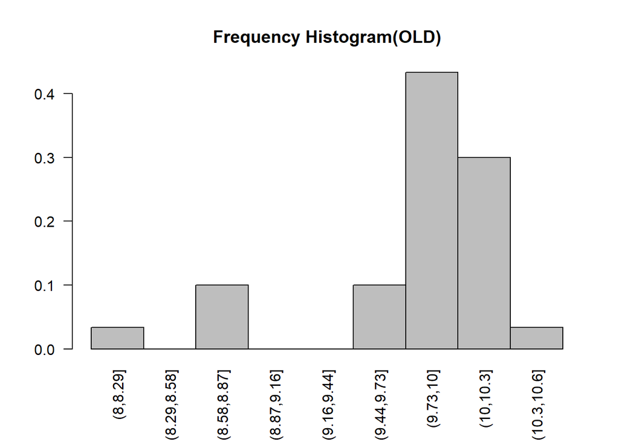

```r
cvtn<-cut(old_voltages,breaks=cl)
old.tab=table(cvtn)/30
barplot(old.tab,space=0,main="Frequency Histogram(OLD)",las=2)
```

2. Construct a stem-and-leaf display for the voltage readings of the old process. Which of the two graphs in parts a and b is more informative about where most of the voltage readings lie? Use the stem() function in R.

```r
stem(old_voltages)
```

```
##
##   The decimal point is at the |
##
##    8 | 1
##    8 | 778
##    9 |
##    9 | 677888899
##   10 | 0000000011122333
##   10 | 6
```

I find that the histogram is more informative about where most of the voltage readings lie, while the stem-and-leaf is more useful for looking at individual data points.

3. Construct a relative frequency histogram for the voltage readings of the new process. Use R to make the histogram. Do NOT use hist()

```r
new<-subset(voltage,subset=LOCATION=="NEW")
new_voltages <- new$VOLTAGE
max(new_voltages)
```

```
## [1] 10.12
```

```r
min(new_voltages)
```

```
## [1] 8.51
```

```r
leptn<-min(new_voltages)-0.05
reptn<-max(new_voltages)+0.05
rngen<-rept-lept
incn<-rnge/9
incn
```

```
## [1] 0.2888889
```

```r
seq(lept, rept,by=inc)->cln
cln
```

```
##  [1]  8.000000  8.288889  8.577778  8.866667  9.155556  9.444444  9.733333
##  [8] 10.022222 10.311111 10.600000
```

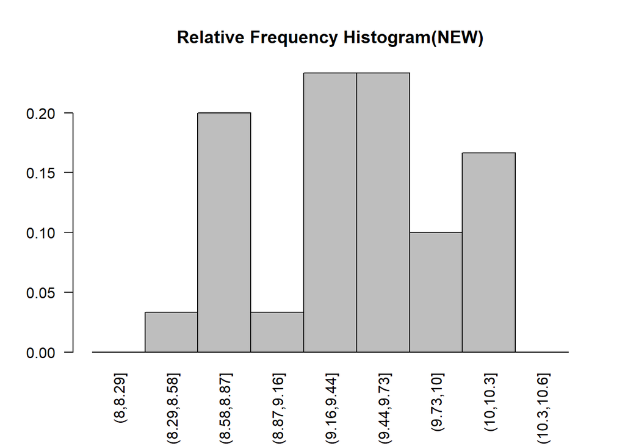

```r
cvtn<-cut(new_voltages,breaks=cln)
new.tab=table(cvtn)/30
barplot(new.tab,space=0,main="Relative Frequency Histogram(NEW)",las=2)
```

4. Compare the two graphs in parts a and c. (You may want to draw the two histograms on the same graph.) Does it appear that the manufacturing process can be established locally (i.e., is the new process as good as or better than the old)?

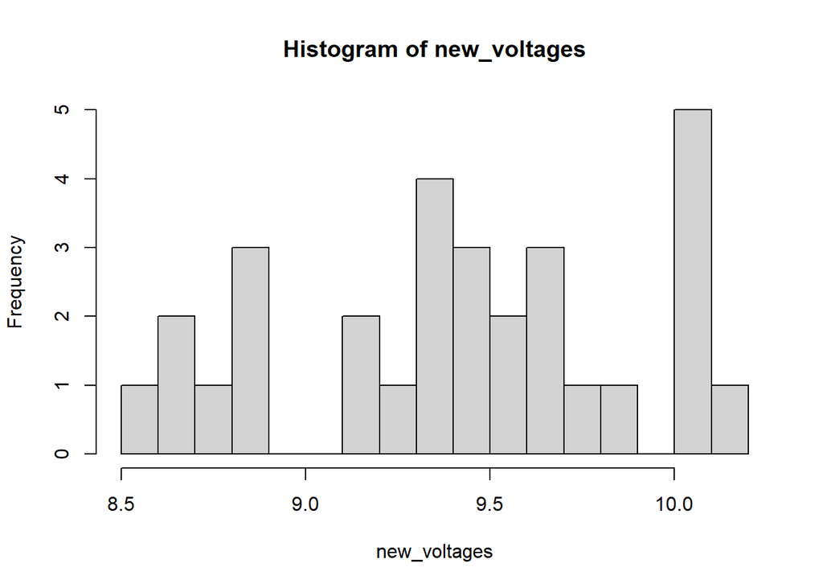

```r
hist(new_voltages,nclass=15)
```

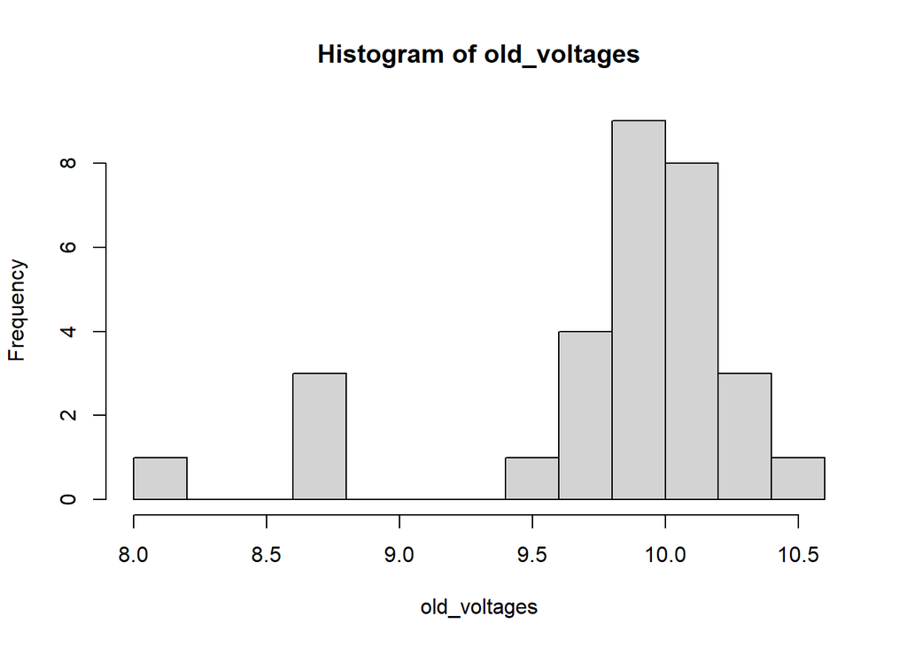

```r
hist(old_voltages,nclass=15)
```

The new process seems to be OK. Though, the old process had more results above the “good” threshold while the new process has fewer above the “good” threshold.

5. Find and interpret the mean, median, and mode for each of the voltage readings data sets. Which is the preferred measure of central tendency? Explain.

```r
getmode <- function(data) {
  counts <- table(data)
  max_count <- max(counts)
  modes <- as.numeric(names(counts)[which(counts == max_count)])
  return(modes)
}

# Old
mean(old_voltages)
```

```
## [1] 9.803667
```

```r
median(old_voltages)
```

```
## [1] 9.975
```

```r
getmode(old_voltages)
```

```
## [1]  8.72  9.80  9.84  9.87  9.98 10.05 10.15 10.26
```

```r
# New
mean(new_voltages)
```

```
## [1] 9.422333
```

```r
median(new_voltages)
```

```
## [1] 9.455
```

```r
getmode(new_voltages)
```

```
## [1] 8.82
```

In this case, the mode is mostly useless for measuring central tendency in both datasets (especially the old set, since there are multiple). For both sets the median is preferred since the median values are not affected by extreme values.

6. Calculate the z-score for a voltage reading of 10.50 at the old location.

```r
x <- 10.50
old_sd <- sd(old_voltages)
old_mean <- mean(old_voltages)
(x - old_mean) / old_sd
```

```
## [1] 1.287324
```

7. Calculate the z-score for a voltage reading of 10.50 at the new location.

```r
x <- 10.50
new_sd <- sd(new_voltages)
new_mean <- mean(new_voltages)
(x - new_mean) / new_sd
```

```
## [1] 2.25041
```

8. Based on the results of parts f and g, at which location is a voltage reading of 10.50 more likely to occur? Explain.

   A reading of 10.50 is more likely to occur at the old location. We know this since the closer a z-score is to 0, the closer the value is to the mean.
9. Construct a box plot for the data at the old location. Do you detect any outliers?

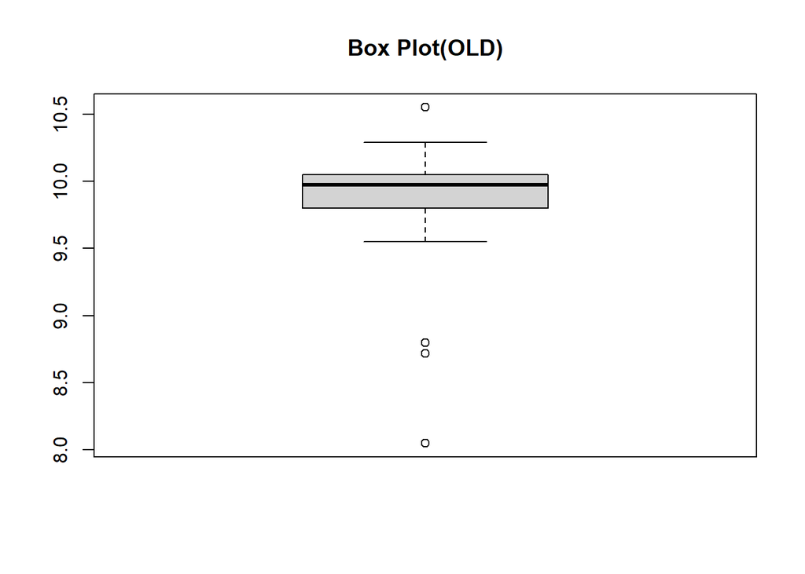

```r
boxplot(old_voltages, main = "Box Plot(OLD)")
```

From the boxplot we can see 4 possible outliers, one above the mean and 3 below the mean.

10. Use the method of z-scores to detect outliers at the old location.

```r
old_z_scores <- (old_voltages - old_mean) / old_sd
old_voltages[abs(old_z_scores) > 3]
```

```
## [1] 8.05
```

Detected one outlier: 8.05.

11. Construct a box plot for the data at the new location. Do you detect any outliers?

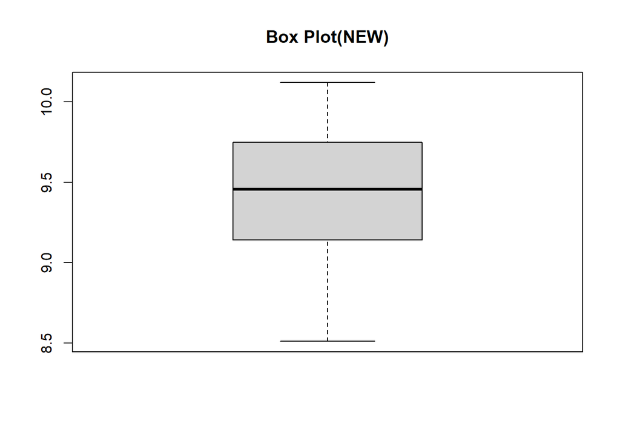

```r
boxplot(new_voltages, main = "Box Plot(NEW)")
```

Using the boxplot, not outliers are detected.

12. Use the method of z-scores to detect outliers at the new location.

```r
new_z_scores <- (new_voltages - new_mean) / new_sd
new_voltages[abs(new_z_scores) > 3]
```

```
## numeric(0)
```

No outliers detected.

13. Compare the distributions of voltage readings at the two locations by placing the box plots, parts i and k, side by side vertically.

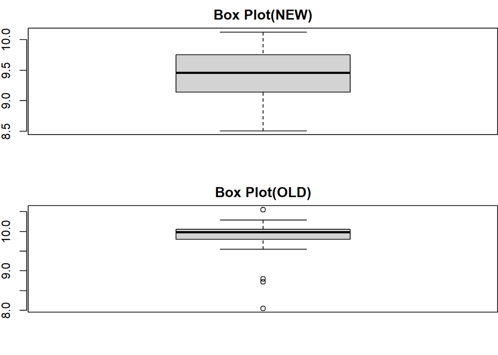

```r
par(mfrow = c(2, 1), mar = c(5, 4, 4, 2) -2, mgp = c(2.5, 1, 0) + 0.1)
boxplot(new_voltages, main = "Box Plot(NEW)")
boxplot(old_voltages, main = "Box Plot(OLD)")
```

The distribution of voltages between locations is different, with the old location having a much tighter IQR than the new location. The new location shows fewer outliers than the old location.

## 12

*Surface roughness of pipe.* Refer to the Anti-corrosion Methods and Materials (Vol. 50, 2003) study of the surface roughness of coated oil field pipes, Exercise 2.20 (p. 37). The data (in micrometers) are repeated in the table. Give an interval that will likely contain about 95% of all coated pipe roughness measurements.

```r
roughpipe <- read.csv("ROUGHPIPE.csv")

#Emperical
sd <- sd(roughpipe$ROUGH)
c <- 2*sd
m <- mean(roughpipe$ROUGH)
m+c
```

```
## [1] 2.928823
```

```r
m-c
```

```
## [1] 0.8331772
```

```r
#Chebyshev
k = 4.47
ch <- k*sd
m + ch
```

```
## [1] 4.222884
```

```r
m - ch
```

```
## [1] -0.460884
```

Using the emperical rule, we can it is likely that 95% of all measurements are within the interval (0.833, 2.93). Using Chebyshev’s rule, we can guarantee that at least 95% of all measurements will be within (-0.461, 4.22).

## 13

*Mongolian desert ants.* The Journal of Biogeography (Dec. 2003) published an article on the first comprehensive study of ants in Mongolia (Central Asia). Botanists placed seed baits at 11 study sites and observed the ant species attracted to each site. Some of the data recorded at each study site are provided in the table at the top of p. 73.

```r
ants <- read.csv("GOBIANTS.csv")
head(ants)
```

```
##   Site      Region Rain Temp PlantCov AntSpecies Diversity
## 1    1  Dry Steppe  196  5.7       40          3      0.89
## 2    2  Dry Steppe  196  5.7       52          3      0.83
## 3    3  Dry Steppe  179  7.0       40         52      1.31
## 4    4  Dry Steppe  197  8.0       43          7      1.48
## 5    5  Dry Steppe  149  8.5       27          5      0.97
## 6    6 Gobi Desert  112 10.7       30         49      0.46
```

```r
ants2 = within(ants,
                 {reg <- ifelse(Region == "Gobi Desert", "GS","DS")
                  reg<-factor(reg) # Make it a factor
                 })
```

1. Find the mean, median, and mode for the number of ant species discovered at the 11 sites. Interpret each of these values.

```r
mean(ants$AntSpecies)
```

```
## [1] 12.81818
```

```r
median(ants$AntSpecies)
```

```
## [1] 5
```

```r
getmode(ants$AntSpecies)
```

```
## [1] 4 5
```

The mean tells us that on average there are 12.8 ant species per site. The median tells us half of the sites had more than 5 ant species, and half of the sites had less than 5 species. The mode tells us the most common numbers of species per site was 4 and 5.

2. Which measure of central tendency would you recommend to describe the center of the number of ant species distribution? Explain.

   For this dataset, the measure of central tendency I would recommend to describe the center of the number of ant species distribution is the median, since it is the center and is less affected by extreme values.
3. Find the mean, median, and mode for the total plant cover percentage at the 5 Dry Steppe sites only.

```r
steppe <- subset(ants2, reg=="DS",)
mean(steppe$PlantCov)
```

```
## [1] 40.4
```

```r
median(steppe$PlantCov)
```

```
## [1] 40
```

```r
getmode(steppe$PlantCov)
```

```
## [1] 40
```

4. Find the mean, median, and mode for the total plant cover percentage at the 6 Gobi Desert sites only.

```r
gobi <- subset(ants2, reg=="GS",)
mean(gobi$PlantCov)
```

```
## [1] 28
```

```r
median(gobi$PlantCov)
```

```
## [1] 26
```

```r
getmode(gobi$PlantCov)
```

```
## [1] 30
```

5. Based on the results, parts c and d, does the center of the total plant cover percentage distribution appear to be different at the two regions?

## 14

*Speed of light from galaxies.* Astronomers theorize that cold dark matter (CDM) caused the formation of galaxies. The theoretical CDM model requires an estimate of the velocity of light emitted from the galaxy. The Astronomical Journal (July, 1995) published a study of galaxy velocities. One galaxy, named A1775, is thought to be a double cluster; that is, two clusters of galaxies in close proximity. Fifty-one velocity observations (in kilometers per second, km/s) from cluster A1775 are listed in the table.

```r
galaxy2 <- read.csv("GALAXY2.csv")
```

1. Use a graphical method to describe the velocity distribution of galaxy cluster A1775.

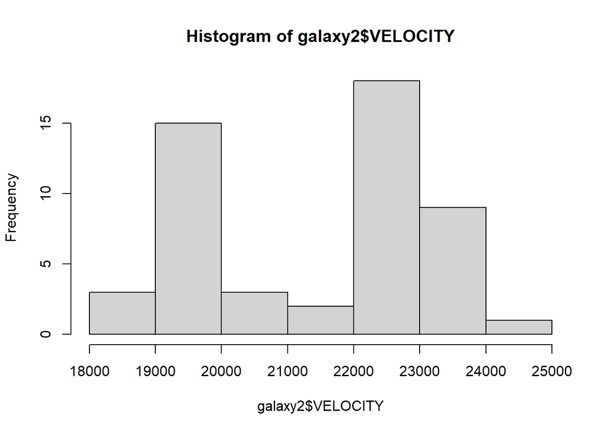

```r
hist(galaxy2$VELOCITY)
```

2. Examine the graph, part a. Is there evidence to support the double cluster theory? Explain.

   Yes, the distribution appears bimodal. This seems like evidence to support the double cluster theory.
3. Calculate numerical descriptive measures (e.g., mean and standard deviation) for galaxy velocities in cluster A1775. Depending on your answer to part b, you may need to calculate two sets of numerical descriptive measures, one for each of the clusters (say, A1775A and A1775B) within the double cluster.

```r
A1775A <- subset(galaxy2, VELOCITY <= 21000)
A1775B <- subset(galaxy2, VELOCITY > 21000)

print("A1775A")
```

```
## [1] "A1775A"
```

```r
summary(A1775A$VELOCITY)
```

```
##    Min. 1st Qu.  Median    Mean 3rd Qu.    Max.
##   18499   19111   19408   19462   19740   20785
```

```r
sd(A1775A$VELOCITY)
```

```
## [1] 532.2868
```

```r
print("A1775B")
```

```
## [1] "A1775B"
```

```r
summary(A1775B$VELOCITY)
```

```
##    Min. 1st Qu.  Median    Mean 3rd Qu.    Max.
##   21911   22541   22780   22838   23106   24909
```

```r
sd(A1775B$VELOCITY)
```

```
## [1] 560.9767
```

4. Suppose you observe a galaxy velocity of 20,000 km/s. Is this galaxy likely to belong to cluster A1775A or A1775B? Explain.

   It is more likely to belong to cluster A1775A, since its center (mean & median) is around 20,000 km/s. And A1775B Does not even include velocities of 20,000 km/s (its minimum is about 22,000 km/s).

## 15

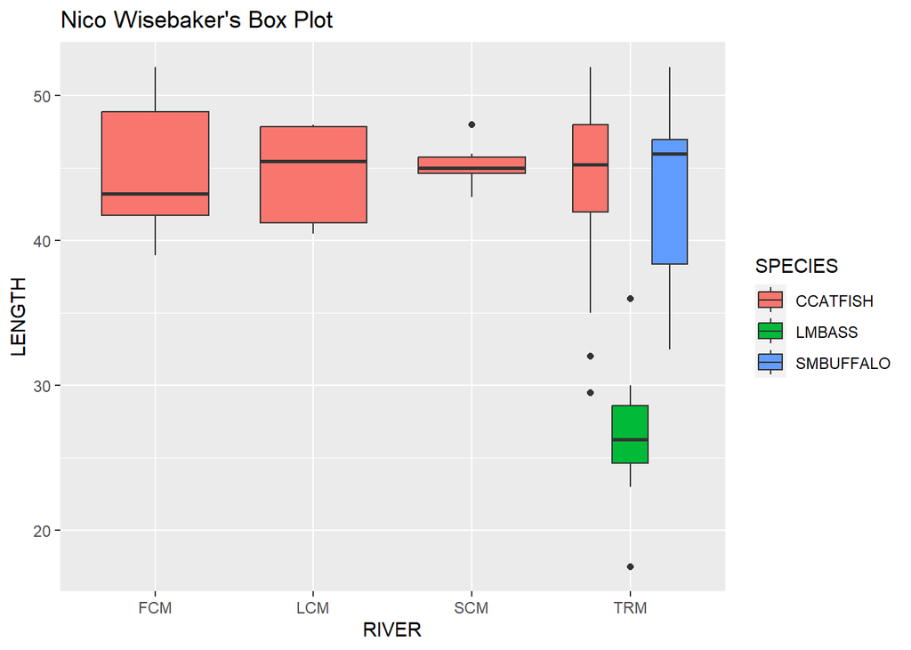

```r
library(ggplot2)
ggplot(data = ddt, aes(x = RIVER, y = LENGTH, fill  = SPECIES)) + geom_boxplot() + ggtitle("Nico Wisebaker's Box Plot")
```